# Исследование графических маркеров юмора в неформальной интернет-переписке

Полина Меньшова

2025-06-22

```r
options(repos = c(CRAN = "https://cran.rstudio.com"))

install.packages("interactions")
install.packages("kableExtra")
install.packages("pwr")
library(kableExtra)
library(tidyverse)
library(ggpubr)
library(rstatix)
library(viridis)
library(pwr)
library(interactions)
```

# Обзор релевантных исследований

Исследований, посвящённых непосредственно маркерам иронии в интернет-коммуникации, относительно немного. При этом существующие работы фокусируются прежде всего на лексических признаках (Гуторина, 2019), а в единственной статье об автоматическом обнаружении иронии в тексте на русском языке, не уделяется внимание анализу предикторов рассматриваемых моделей (Kosterin et al, 2023). Однако есть ряд работ на смежные темы. Рассмотрим наиболее релевантные из них

Francisco Yus в статье Inferring Irony Online (2023) описывает спектр контекстуальной информации, которая позволяет людям успешно использовать и считывать иронию, даже если они находятся вдали друг от друга — например, в ситуации онлайн-переписки. К таким сведениям исследователь относит так называемые базовые (широко распространённые) знания, специфические знания конкретного носителя языка, предыдущие высказывания в диалоге, лингвистические подсказки (в частности, графические маркеры) и информацию о текущей физической обстановке. Согласно этой статье, ирония не мешает коммуникации, поскольку перечисленные факторы сочетаются особым образом в каждой конкретной ситуации.

Albert N. Katz в исследовании Pictorial Irony and Sarcasm (2023) сравнивает иронию и сарказм с точки зрения теории векторного пространства и показывает, что сарказм более мрачен и агрессивен. В нашем проекте сарказм и ирония не разграничиваются ввиду ограничений датасета, однако стоит учесть это в дальнейшем.

В работе Studying Irony Detection Beyond Ironic Criticism: Let’s Include Ironic Praise (Bruntsch & Ruch, 2017) внимание сфокусировано на способности человека распознавать иронию в зависимости от тональности, а также на разработке инструмента для оценивания этой способности. С помощью специального опросника TOVIDA авторы сделали выводы о том, насколько хорошо люди считывают иронию как таковую, и вместе с тем выяснили, что ироничная похвала распознаётся хуже, чем ироничная критика.

# Загрузка и описание данных

```r
df <- read_csv("https://raw.githubusercontent.com/menshova19/University_Projects/main/Dataset%20R%20filled.csv")
glimpse(df)
```

```
## Rows: 140
## Columns: 64
## $ user_id                <dbl> 1, 2, 3, 4, 5, 6, 7, 8, 9, 10, 11, 12, 13, 14, …
## $ age                    <dbl> 21, 20, 21, 23, 22, 17, 43, 17, 26, 27, 18, 22,…
## $ felt_confused          <chr> "yes", "no", "yes", "yes", "yes", "yes", "yes",…
## $ exclam_confuse         <chr> "no", "no", "no", "None", "no", "no", "None", "…
## $ exclam_digit_confuse   <chr> "no", "no", "no", "None", "yes", "no", "None", …
## $ end_punct_confuse      <chr> "no", "no", "no", "None", "no", "no", "None", "…
## $ excess_punct_confuse   <chr> "no", "no", "no", "None", "yes", "yes", "None",…
## $ too_serious_confuse    <chr> "no", "no", "no", "None", "no", "no", "None", "…
## $ laughter_confuse       <chr> "no", "no", "no", "None", "no", "no", "None", "…
## $ capslock_confuse       <chr> "no", "no", "no", "None", "no", "yes", "None", …
## $ literary_confuse       <chr> "no", "no", "no", "None", "no", "no", "None", "…
## $ ellipsis_confuse       <chr> "no", "no", "no", "None", "no", "no", "None", "…
## $ punct_pres_confuse     <chr> "no", "no", "no", "None", "no", "no", "None", "…
```

[output cut: 51 more lines]

```r
head(df)
```

```
## # A tibble: 6 × 64
##   user_id   age felt_confused exclam_confuse exclam_digit_confuse
##     <dbl> <dbl> <chr>         <chr>          <chr>
## 1       1    21 yes           no             no
## 2       2    20 no            no             no
## 3       3    21 yes           no             no
## 4       4    23 yes           None           None
## 5       5    22 yes           no             yes
## 6       6    17 yes           no             no
## # ℹ 59 more variables: end_punct_confuse <chr>, excess_punct_confuse <chr>,
## #   too_serious_confuse <chr>, laughter_confuse <chr>, capslock_confuse <chr>,
## #   literary_confuse <chr>, ellipsis_confuse <chr>, punct_pres_confuse <chr>,
## #   bracket_confuse <chr>, emoji_confuse <chr>, typo_confuse <chr>,
## #   atypical_style_confuse <chr>, no_emoji_confuse <chr>,
## #   no_exclam_confuse <chr>, no_punct_confuse <chr>, no_laughter_confuse <chr>,
## #   no_capslock_confuse <chr>, no_typo_confuse <chr>, …
```

В первой части опроса респонденты указывали свой возраст, а также сообщали о своём опыте распознавания и выражения комического в интернет-переписке. Далее им предлагалось оценить степень ироничности одного и того же высказывания с разным графическим оформлением по шкале от 1 до 5, где 1 — максимально серьёзное высказывание, 5 — максимально ироничное высказывание. В качестве “экспериментального” высказывания использовалось утверждение “Я чувствую себя как функция арктангенса, стремящаяся к асимптоте”, а респонденты дополнительно отмечали, знакомы ли с математическими терминами, использованными в опросе.

Стоит отметить, что каждый человек, участвовавший в опросе, оценивал все виды стимулов, и показывались они в одном и том же порядке. Это важно учитывать при интерпретации и использовании результатов исследования.

Таблица с ответами респондентов была преобразована с помощью сервиса Google Sheets и языка программирования Python. После преобразования в ней имеются следующие колонки:

user_id — id респондента

age — возраст респондента

felt_confused — ответ на вопрос о том, бывало ли респонденту трудно понять, серьёзен онлайн-собеседник или шутит

Названия колонок с пометкой _confuse содержат обозначения графических средств выражения комического, которые были упомянуты в ответах опрошенных как причины, по которым характер сообщений собеседников не был им ясен. В самих колонках - ответы респондентов на вопрос о том, вызывало ли то или иное средство у них сомнения (yes/no). В случае отсутствия ответа на вопрос в ячейке указывалось None.

exclam_confuse — восклицательный знак или восклицательные знаки

exclam_digit_confuse — восклицательные знаки и единицы

end_punct_confuse — знаки препинания в конце предложения

excess_punct_confuse — избыточная пунктуация

too_serious_confuse — подчёркнутая серьёзность

laughter_confuse — имитация смеха (“хахаха”, “ахаах” и т. д.)

capslock_confuse — капслок, то есть использование только верхнего регистра

literary_confuse — подчёркнутая литературность

ellipsis_confuse — многоточие или многоточия

punct_pres_confuse — наличие пунктуации

bracket_confuse — скобки

emoji_confuse — эмодзи

typo_confuse — нарочитые ошибки и опечатки

atypical_style_confuse — нетипичный стиль сообщения

no_emoji_confuse — отсутствие эмодзи

no_exclam_confuse — отсутствие восклицательного знака

no_punct_confuse — отсутствие пунктуации

no_laughter_confuse — отсутствие имитации смеха

no_capslock_confuse — отсутствие капслока

no_typo_confuse — отсутствие нарочитых ошибок и опечаток

no_direct_confuse — отсутствие прямого указания на шутку

no_bracket_confuse — отсутствие скобок

no_dot_confuse — отсутствие точек

typical_style_confuse — типичный стиль

tone_shift_confuse — резкая смена тона

end_dash_confuse — тире в конце сообщения

dot_bracket_confuse — точка со скобкой

dot_confuse — точка

Названия следующих колонок устроены схожим образом: они содержат обозначения графических средств выражения комического и пометку _use. В самих колонках — ответы на вопрос о том, использует ли респондент то или иное средство в собственных сообщениях (yes/no). В случае отсутствия ответа указано None.

emoji_use — эмодзи

exclam_use — восклицательный знак или восклицательные знаки

exclam_digit_use — восклицательные знаки и единицы

zaborchik_use — чередование регистров (зАбОрЧиК)

stars_use — звёздочки

excess_punct_use — избыточная пунктуация

laughter_use — имитация смеха (“хахаха”, “ахахах” и т. д.)

quotes_use — кавычки

kaomoji_use — каомодзи, например („• ֊ •„)

capslock_use — капслок

italic_use — курсив

ellipsis_use — многоточие или многоточия

typo_use — нарочитые ошибки и опечатки

case_misuse — нестандартное использование регистра

atypical_style_use — нетипичный стиль

direct_use — прямое указание на шутку

bracket_use — скобки

bracket_zero_use — скобки и нули

lol_word_use — слова наподобие “лол” и “кек”

end_dash_use — тире в конце сообщения

tone_j_use — тонтег /j

tone_psh_use — тонтег /пш

tone_sh_use — тонтег /ш

dot_use — точка

letter_repeat_use — умножение букв

Следующие колонки отражают результаты второй части опроса, в рамках которой респонденты оценивали, насколько ироничным выглядит одно и то же высказывание, оформленное разными способами.

is_aware — ответ на вопрос о том, известны ли респонденту термины “арктангенс” и “асимптота” (yes/no)

zaborchik_rate — оценка ироничности высказывания, написанного зАбОрЧиКоМ

exclam_digit_rate — оценка ироничности высказывания с восклицательными знаками и единицами

bracket_zero_rate — оценка ироничности высказывания со скобками и нулями

bracket_rate — оценка ироничности высказывания со скобками

exclam_rate — оценка ироничности высказывания с восклицательными знаками

no_dot_rate — оценка ироничности высказывания без точки

capslock_rate — оценка ироничности высказывания, написанного капслоком

# Разведочный анализ

```r
df %>% summarise_all(~sum(is.na(.)))
```

```
## # A tibble: 1 × 64
##   user_id   age felt_confused exclam_confuse exclam_digit_confuse
##     <int> <int>         <int>          <int>                <int>
## 1       0     0             0              0                    0
## # ℹ 59 more variables: end_punct_confuse <int>, excess_punct_confuse <int>,
## #   too_serious_confuse <int>, laughter_confuse <int>, capslock_confuse <int>,
## #   literary_confuse <int>, ellipsis_confuse <int>, punct_pres_confuse <int>,
## #   bracket_confuse <int>, emoji_confuse <int>, typo_confuse <int>,
## #   atypical_style_confuse <int>, no_emoji_confuse <int>,
## #   no_exclam_confuse <int>, no_punct_confuse <int>, no_laughter_confuse <int>,
## #   no_capslock_confuse <int>, no_typo_confuse <int>, …
```

Значение None, использованное в случае отсутствия ответа на тот или иной вопрос, видимо, является строкой, поэтому статистика показывает отсутствие пропущенных значений. Вопрос, правда, стоит ли их чем-то заменять в таком случае…

```r
data_clean <- df %>%
  mutate(across(where(is.character), ~na_if(., "None"))) %>%
  replace(is.na(.), "no")

glimpse(data_clean)
```

```
## Rows: 140
## Columns: 64
## $ user_id                <dbl> 1, 2, 3, 4, 5, 6, 7, 8, 9, 10, 11, 12, 13, 14, …
## $ age                    <dbl> 21, 20, 21, 23, 22, 17, 43, 17, 26, 27, 18, 22,…
## $ felt_confused          <chr> "yes", "no", "yes", "yes", "yes", "yes", "yes",…
## $ exclam_confuse         <chr> "no", "no", "no", "no", "no", "no", "no", "no",…
## $ exclam_digit_confuse   <chr> "no", "no", "no", "no", "yes", "no", "no", "no"…
## $ end_punct_confuse      <chr> "no", "no", "no", "no", "no", "no", "no", "no",…
## $ excess_punct_confuse   <chr> "no", "no", "no", "no", "yes", "yes", "no", "no…
## $ too_serious_confuse    <chr> "no", "no", "no", "no", "no", "no", "no", "no",…
## $ laughter_confuse       <chr> "no", "no", "no", "no", "no", "no", "no", "no",…
## $ capslock_confuse       <chr> "no", "no", "no", "no", "no", "yes", "no", "no"…
## $ literary_confuse       <chr> "no", "no", "no", "no", "no", "no", "no", "no",…
## $ ellipsis_confuse       <chr> "no", "no", "no", "no", "no", "no", "no", "no",…
## $ punct_pres_confuse     <chr> "no", "no", "no", "no", "no", "no", "no", "no",…
```

[output cut: 51 more lines]

```r
head(data_clean)
```

```
## # A tibble: 6 × 64
##   user_id   age felt_confused exclam_confuse exclam_digit_confuse
##     <dbl> <dbl> <chr>         <chr>          <chr>
## 1       1    21 yes           no             no
## 2       2    20 no            no             no
## 3       3    21 yes           no             no
## 4       4    23 yes           no             no
## 5       5    22 yes           no             yes
## 6       6    17 yes           no             no
## # ℹ 59 more variables: end_punct_confuse <chr>, excess_punct_confuse <chr>,
## #   too_serious_confuse <chr>, laughter_confuse <chr>, capslock_confuse <chr>,
## #   literary_confuse <chr>, ellipsis_confuse <chr>, punct_pres_confuse <chr>,
## #   bracket_confuse <chr>, emoji_confuse <chr>, typo_confuse <chr>,
## #   atypical_style_confuse <chr>, no_emoji_confuse <chr>,
## #   no_exclam_confuse <chr>, no_punct_confuse <chr>, no_laughter_confuse <chr>,
## #   no_capslock_confuse <chr>, no_typo_confuse <chr>, …
```

```r
# Описательная статистика по возрасту

data_clean %>% summarise(
  min_age = min(age, na.rm=TRUE),
  max_age = max(age, na.rm=TRUE),
  mean_age = mean(age, na.rm=TRUE),
  median_age = median(age, na.rm=TRUE),
  sd_age = sd(age, na.rm=TRUE)
)
```

```
## # A tibble: 1 × 5
##   min_age max_age mean_age median_age sd_age
##     <dbl>   <dbl>    <dbl>      <dbl>  <dbl>
## 1      13      55     22.2         21   6.99
```

Средний возраст участников опроса — чуть больше 22 лет, медианное значение возраста — 21 год. Самому молодому респонденту 13 лет, а самому взрослому — 55 лет. Стандартное отклонение от среднего составляет почти 7 лет.

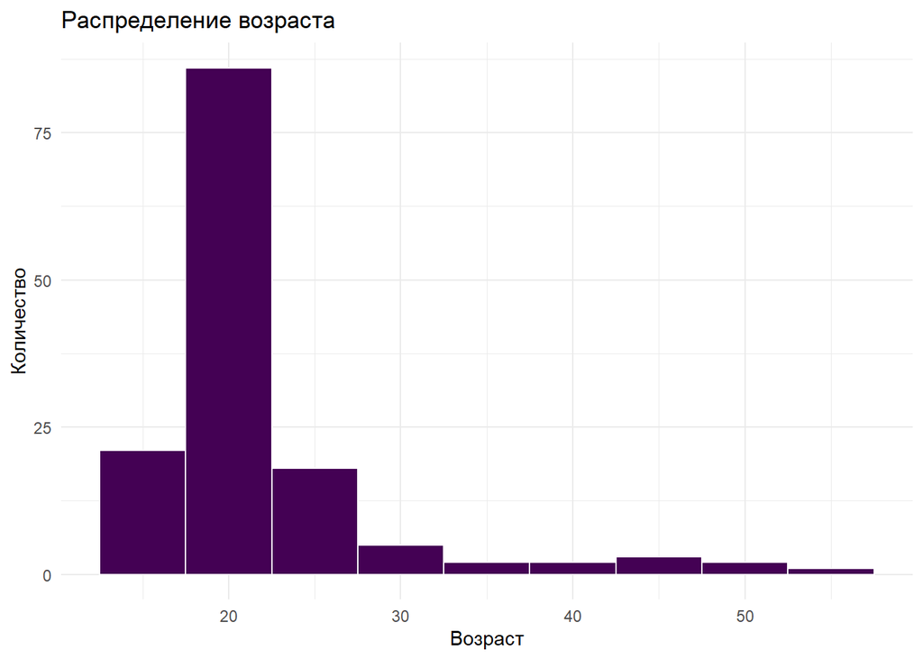

```r
# Гистограмма распределения возраста
ggplot(data_clean, aes(x=age)) +
  geom_histogram(binwidth=5, fill=viridis(1), color="white") +
  labs(title="Распределение возраста", x="Возраст", y="Количество") +
  theme_minimal()
```

По графику распределения видно, что оно несимметрично и более половины выборки составляют респонденты в возрасте 20-25 лет. На втором месте — люди младше 20 лет. Респондентов от 30 лет намного меньше, что стоит учитывать при интерпретации результатов дальнейшего анализа.

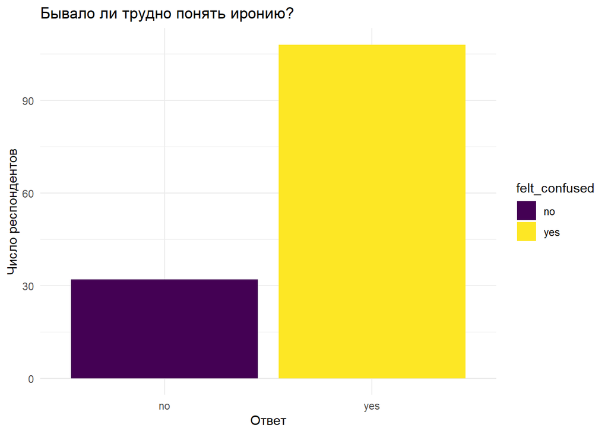

```r
# Распределение по felt_confused

data_clean %>%
  count(felt_confused) %>%
  ggplot(aes(x=felt_confused, y=n, fill=felt_confused)) +
  geom_col() +
  scale_fill_viridis_d() +
  labs(title="Бывало ли трудно понять иронию?", x="Ответ", y="Число респондентов") +
  theme_minimal()
```

Более 75% опрошенных сталкивались с трудностями, пытаясь определить, серьёзен их онлайн-собеседник или шутит.

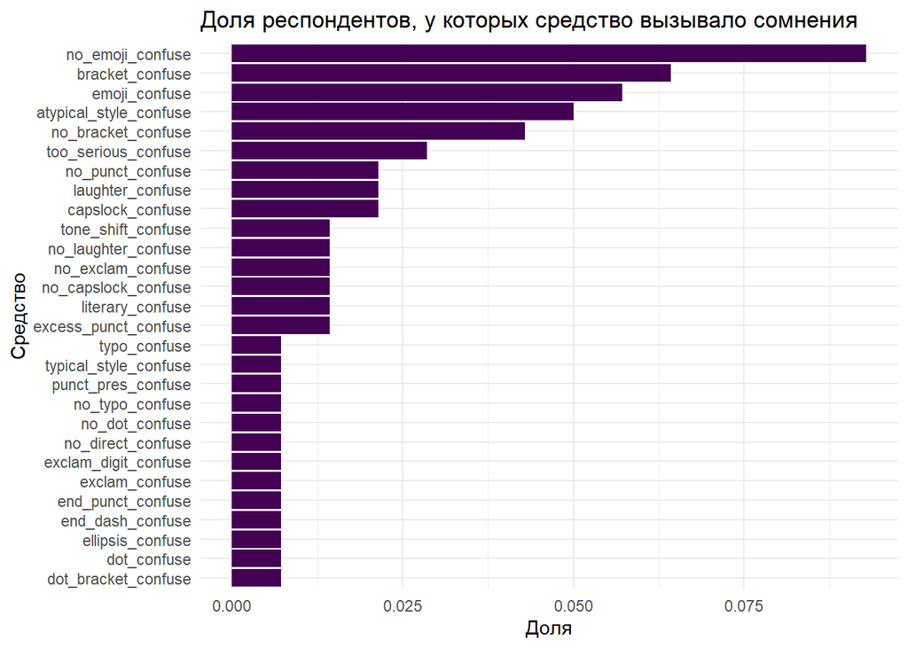

```r
# Доля сомнений по графическим средствам

data_clean %>%
  select(ends_with("_confuse")) %>%
  summarise_all(~mean(. == "yes", na.rm=TRUE)) %>%
  pivot_longer(everything(), names_to="feature", values_to="prop_confuse") %>%
  ggplot(aes(x=reorder(feature, prop_confuse), y=prop_confuse)) +
  geom_col(fill=viridis(1)) +
  coord_flip() +
  labs(title="Доля респондентов, у которых средство вызывало сомнения", x="Средство", y="Доля") +
  theme_minimal()
```

Чаще всего причинами для сомнений становились следующие графические средства: отсутствие эмодзи, наличие скобок, наличие эмодзи, нетипичный стиль сообщения и отсутствие скобок.

Напротив, реже всего вызывали сомнения в серьёзности собеседника такие графические средства, как нарочитые опечатки и ошибки, типичный стиль сообщения, правильная постановка знаков препинания, отсутствие нарочитых ошибок и опечаток, отсутствие точек, отсутствие прямого указания на шутку, использование восклицательных знаков и единиц, использование восклицательных знаков, наличие знаков препинания в конце сообщения, тире в конце сообщения, наличие многоточий, наличие точек и наличие точки со скобкой.

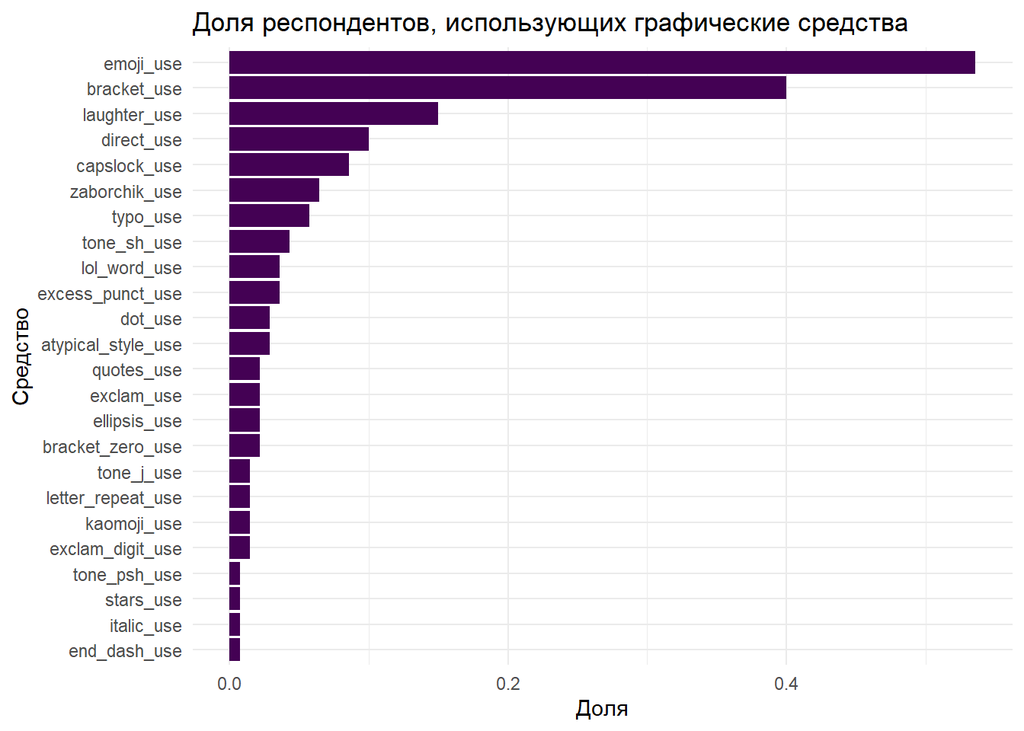

```r
# Пропорции использования основных графических средств

df %>%
  select(ends_with("_use")) %>%
  summarise_all(~mean(. == "yes", na.rm=TRUE)) %>%
  pivot_longer(everything(), names_to="feature", values_to="prop_use") %>%
  ggplot(aes(x=reorder(feature, prop_use), y=prop_use)) +
  geom_col(fill = viridis(1)) +
  coord_flip() +
  labs(title="Доля респондентов, использующих графические средства", x="Средство", y="Доля") +
  theme_minimal()
```

Сами респонденты, когда хотят подчеркнуть ироничный тон сообщения, чаще всего используют эмодзи, скобки, имитацию смеха, прямое указание на шутку и капслок. Наименее популярные графические средства выражения комического: тонтег /пш, звёздочки, курсив и тире в конце сообщения.

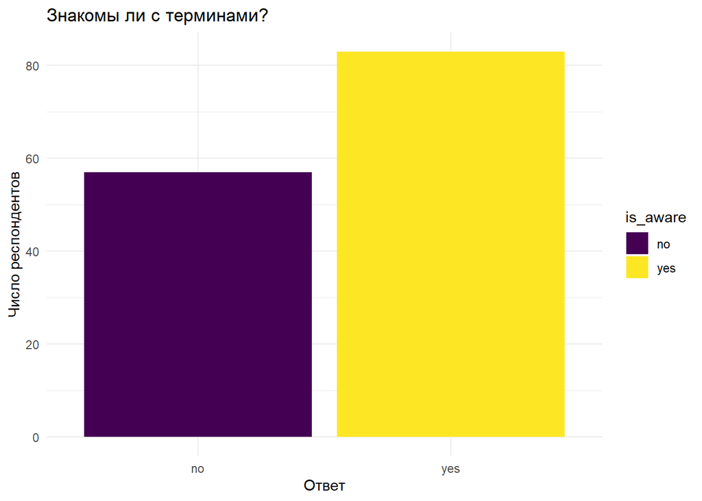

```r
# Распределение по знанию терминов "арктангенс" и "асимптота"

data_clean %>%
  count(is_aware) %>%
  ggplot(aes(x=is_aware, y=n, fill=is_aware)) +
  geom_col() +
  scale_fill_viridis_d() +
  labs(title="Знакомы ли с терминами?", x="Ответ", y="Число респондентов") +
  theme_minimal()
```

```r
# Описательная статистика по оценкам ироничности

data_clean %>%
  select(ends_with("_rate")) %>%
  summary()
```

```
##  zaborchik_rate  exclam_digit_rate bracket_zero_rate  bracket_rate
##  Min.   :1.000   Min.   :1.0       Min.   :1.000     Min.   :1.000
##  1st Qu.:3.000   1st Qu.:2.0       1st Qu.:3.000     1st Qu.:3.000
##  Median :4.000   Median :3.0       Median :4.000     Median :4.000
##  Mean   :3.871   Mean   :3.3       Mean   :4.014     Mean   :3.771
##  3rd Qu.:5.000   3rd Qu.:5.0       3rd Qu.:5.000     3rd Qu.:5.000
##  Max.   :5.000   Max.   :5.0       Max.   :5.000     Max.   :5.000
##   exclam_rate   no_dot_rate    capslock_rate
##  Min.   :1.0   Min.   :1.000   Min.   :1.000
##  1st Qu.:2.0   1st Qu.:1.000   1st Qu.:2.000
##  Median :2.0   Median :2.000   Median :3.000
##  Mean   :2.4   Mean   :2.307   Mean   :3.114
##  3rd Qu.:3.0   3rd Qu.:3.000   3rd Qu.:4.000
##  Max.   :5.0   Max.   :5.000   Max.   :5.000
```

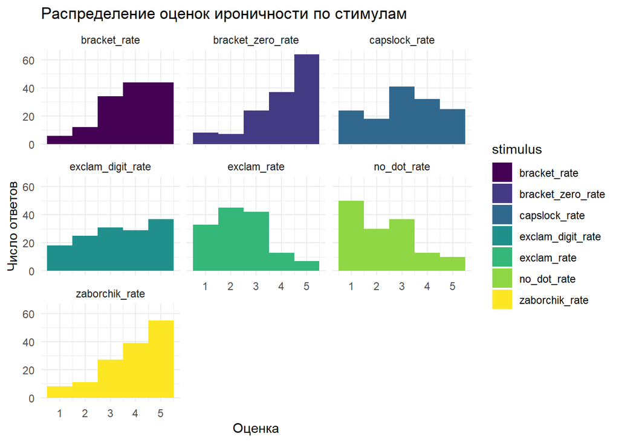

```r
df %>%
  select(ends_with("_rate")) %>%
  pivot_longer(everything(), names_to="stimulus", values_to="rate") %>%
  ggplot(aes(x=rate, fill=stimulus)) +
  geom_histogram(binwidth=1, position="dodge") +
  facet_wrap(~stimulus) +
  scale_fill_viridis_d() +
  labs(title="Распределение оценок ироничности по стимулам", x="Оценка", y="Число ответов") +
  theme_minimal()
```

По графикам видно, что больше всего “пятёрок” получили скобки с нулями, “заборчик” и скобки, а больше всего единиц — отсутствие точки, восклицательные знаки и капслок.

# Основной анализ

H₀: Респонденты, использующие оцениваемые графические средства в своих сообщениях (bracket_use = “yes” и т. д.), не ставят более высокие оценки ироничности стимулам с этими средствами (bracket_rate и т. д.).

```r
feature_rate_map <- list(
  zaborchik = "zaborchik_rate",
  exclam_digit = "exclam_digit_rate",
  bracket_zero = "bracket_zero_rate",
  bracket = "bracket_rate",
  exclam = "exclam_rate",
  capslock = "capslock_rate"
)

graphic_features <- names(feature_rate_map)
```

```r
for (feature in graphic_features) {
  cat("\n\n====================================\n")
  cat("Медианы и средние для графического средства:", feature, "\n")
  cat("====================================\n")

  use_col <- paste0(feature, "_use")
  rate_col <- feature_rate_map[[feature]]

  df_sub <- data_clean %>%
    filter(!is.na(.data[[use_col]]), !is.na(.data[[rate_col]])) %>%
    mutate(use_group = factor(.data[[use_col]], levels = c("no", "yes")))

  stats <- df_sub %>%
    group_by(use_group) %>%
    summarise(
      count = n(),
      median_rate = median(.data[[rate_col]], na.rm = TRUE),
      mean_rate = mean(.data[[rate_col]], na.rm = TRUE)
    )

  print(stats)
}
```

```
##
##
## ====================================
## Медианы и средние для графического средства: zaborchik
## ====================================
## # A tibble: 2 × 4
##   use_group count median_rate mean_rate
##   <fct>     <int>       <dbl>     <dbl>
## 1 no          131           4      3.83
## 2 yes           9           4      4.44
##
##
## ====================================
## Медианы и средние для графического средства: exclam_digit
## ====================================
## # A tibble: 2 × 4
##   use_group count median_rate mean_rate
##   <fct>     <int>       <dbl>     <dbl>
## 1 no          138           3      3.28
## 2 yes           2           5      5
##
##
## ====================================
## Медианы и средние для графического средства: bracket_zero
## ====================================
## # A tibble: 2 × 4
##   use_group count median_rate mean_rate
##   <fct>     <int>       <dbl>     <dbl>
## 1 no          137           4      3.99
## 2 yes           3           5      5
##
##
## ====================================
## Медианы и средние для графического средства: bracket
## ====================================
## # A tibble: 2 × 4
##   use_group count median_rate mean_rate
##   <fct>     <int>       <dbl>     <dbl>
## 1 no           84           4      3.61
## 2 yes          56           4      4.02
##
##
## ====================================
## Медианы и средние для графического средства: exclam
## ====================================
## # A tibble: 2 × 4
##   use_group count median_rate mean_rate
##   <fct>     <int>       <dbl>     <dbl>
## 1 no          137           2      2.36
## 2 yes           3           5      4
##
##
## ====================================
## Медианы и средние для графического средства: capslock
## ====================================
## # A tibble: 2 × 4
##   use_group count median_rate mean_rate
##   <fct>     <int>       <dbl>     <dbl>
## 1 no          128           3      3.04
## 2 yes          12           4      3.92
```

Изначально планировалось использовать t-тест или точный критерий Фишера, если данные окажутся нормально распределёнными. Для анализа распределения я попробовала провести тест Шапиро — Уилка, но это оказалось невозможным для нескольких графических средств, поскольку при делении выборки на группы по использованию конкретного средства образовывались группы численностью меньше 5. В связи с этим было решено для всех графических средств провести тест, не требующий нормально распределённых данных, а именно тест Уилкоксона.

```
##
##
## ====================================
## Анализ графического средства: zaborchik
## ====================================
```

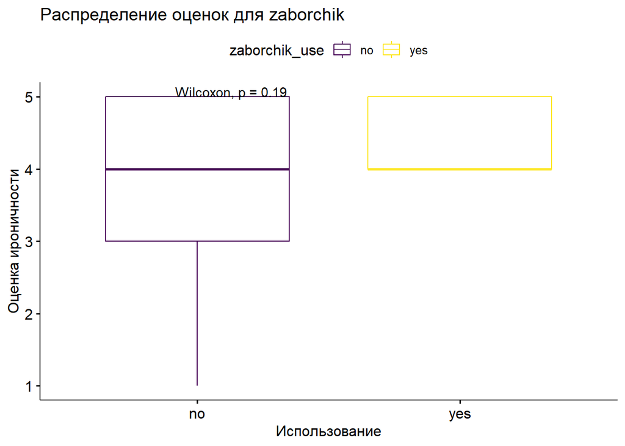

```
##
## Тест Уилкоксона для сравнения средних:
##
##  Wilcoxon rank sum test with continuity correction
##
## data:  rate_var by use_var
## W = 442, p-value = 0.1904
## alternative hypothesis: true location shift is not equal to 0
```

```
##
## Корреляция Спирмена между использованием и оценкой:
##
##  Spearman's rank correlation rho
##
## data:  rate_var and as.numeric(use_var == "yes")
## S = 406352, p-value = 0.19
## alternative hypothesis: true rho is not equal to 0
## sample estimates:
##       rho
## 0.1114294
##
##
## ------------------------------------
##
##
##
## ====================================
## Анализ графического средства: exclam_digit
## ====================================
```

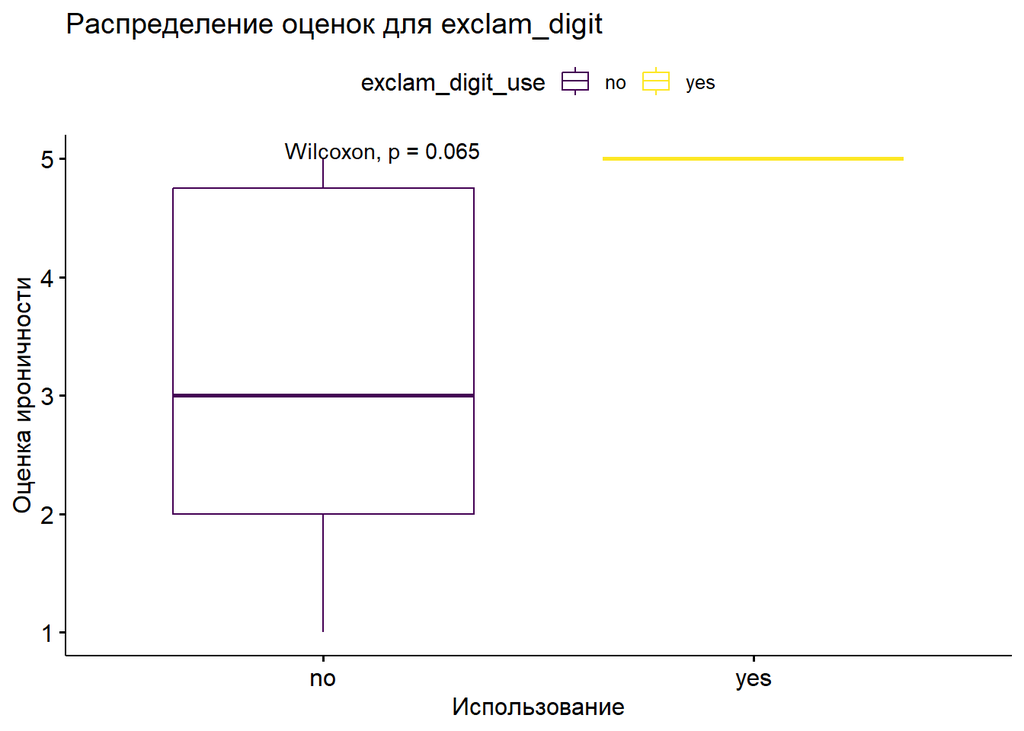

```
##
## Тест Уилкоксона для сравнения средних:
##
##  Wilcoxon rank sum test with continuity correction
##
## data:  rate_var by use_var
## W = 35, p-value = 0.06536
## alternative hypothesis: true location shift is not equal to 0
```

```
##
## Корреляция Спирмена между использованием и оценкой:
##
##  Spearman's rank correlation rho
##
## data:  rate_var and as.numeric(use_var == "yes")
## S = 385483, p-value = 0.06384
## alternative hypothesis: true rho is not equal to 0
## sample estimates:
##      rho
## 0.157064
##
##
## ------------------------------------
##
##
##
## ====================================
## Анализ графического средства: bracket_zero
## ====================================
```

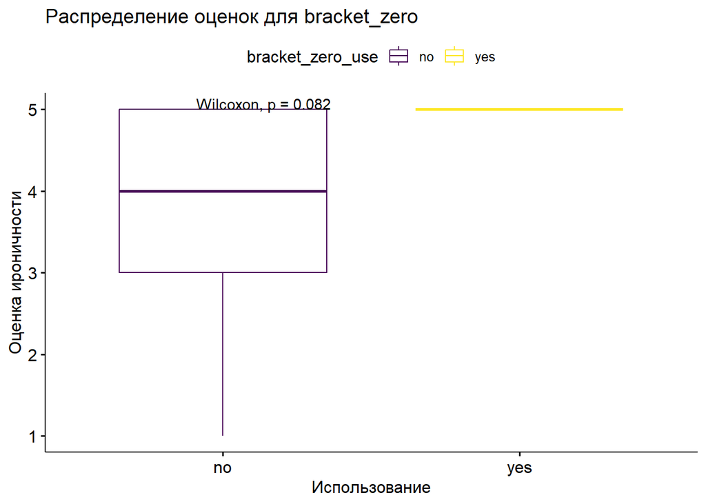

```
##
## Тест Уилкоксона для сравнения средних:
##
##  Wilcoxon rank sum test with continuity correction
##
## data:  rate_var by use_var
## W = 91.5, p-value = 0.08179
## alternative hypothesis: true location shift is not equal to 0
```

```
##
## Корреляция Спирмена между использованием и оценкой:
##
##  Spearman's rank correlation rho
##
## data:  rate_var and as.numeric(use_var == "yes")
## S = 389506, p-value = 0.08042
## alternative hypothesis: true rho is not equal to 0
## sample estimates:
##       rho
## 0.1482665
##
##
## ------------------------------------
##
##
##
## ====================================
## Анализ графического средства: bracket
## ====================================
```

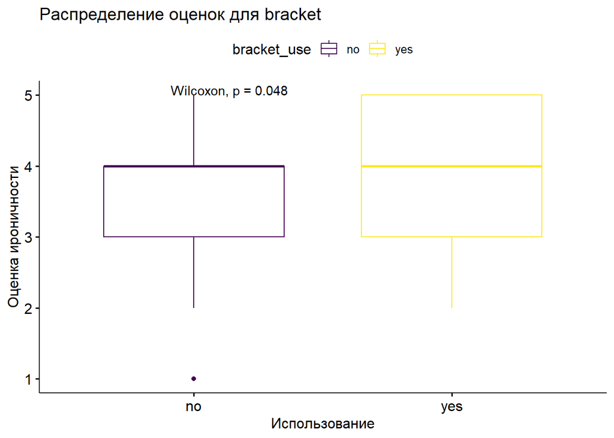

```
##
## Тест Уилкоксона для сравнения средних:
##
##  Wilcoxon rank sum test with continuity correction
##
## data:  rate_var by use_var
## W = 1905, p-value = 0.04805
## alternative hypothesis: true location shift is not equal to 0
```

```
##
## Корреляция Спирмена между использованием и оценкой:
##
##  Spearman's rank correlation rho
##
## data:  rate_var and as.numeric(use_var == "yes")
## S = 380543, p-value = 0.04742
## alternative hypothesis: true rho is not equal to 0
## sample estimates:
##       rho
## 0.1678664
##
##
## ------------------------------------
##
##
##
## ====================================
## Анализ графического средства: exclam
## ====================================
```

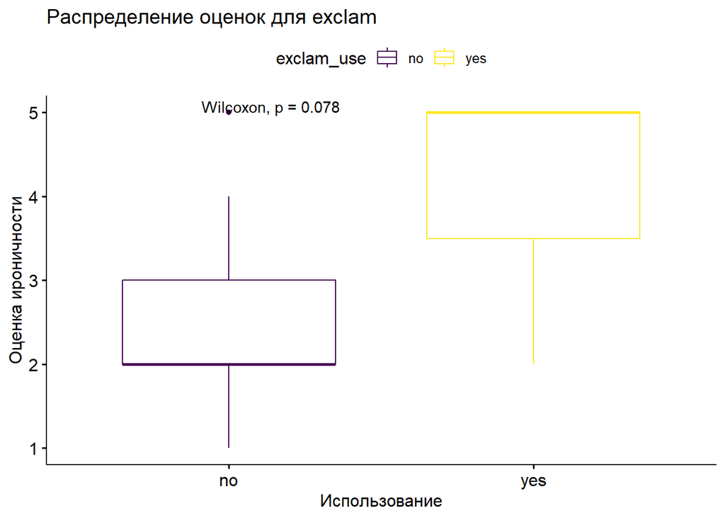

```
##
## Тест Уилкоксона для сравнения средних:
##
##  Wilcoxon rank sum test with continuity correction
##
## data:  rate_var by use_var
## W = 87, p-value = 0.07761
## alternative hypothesis: true location shift is not equal to 0
```

```
##
## Корреляция Спирмена между использованием и оценкой:
##
##  Spearman's rank correlation rho
##
## data:  rate_var and as.numeric(use_var == "yes")
## S = 388568, p-value = 0.07628
## alternative hypothesis: true rho is not equal to 0
## sample estimates:
##       rho
## 0.1503172
##
##
## ------------------------------------
##
##
##
## ====================================
## Анализ графического средства: capslock
## ====================================
```

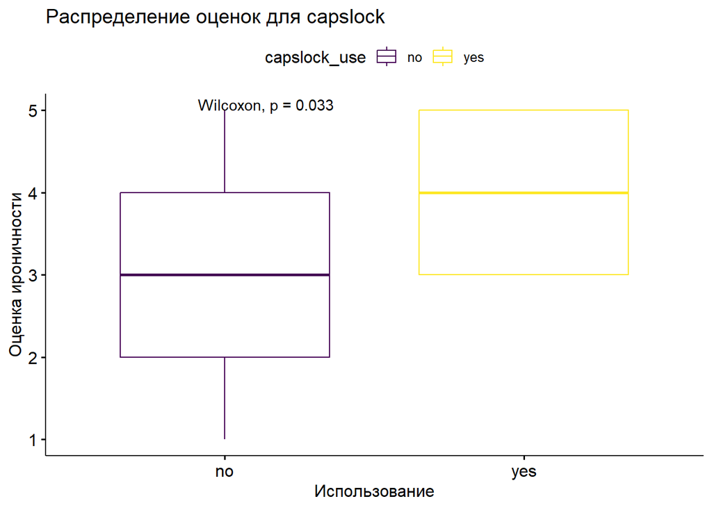

```
##
## Тест Уилкоксона для сравнения средних:
##
##  Wilcoxon rank sum test with continuity correction
##
## data:  rate_var by use_var
## W = 488.5, p-value = 0.03312
## alternative hypothesis: true location shift is not equal to 0
```

```
##
## Корреляция Спирмена между использованием и оценкой:
##
##  Spearman's rank correlation rho
##
## data:  rate_var and as.numeric(use_var == "yes")
## S = 374520, p-value = 0.03231
## alternative hypothesis: true rho is not equal to 0
## sample estimates:
##       rho
## 0.1810372
##
##
## ------------------------------------
```

```r
for (feature in graphic_features) {
  cat("\n\n====================================\n")
  cat("Анализ графического средства:", feature, "\n")
  cat("====================================\n")

  use_var <- factor(data_clean[[paste0(feature, "_use")]], levels = c("no", "yes"))
  rate_var <- data_clean[[feature_rate_map[[feature]]]]

  complete_idx <- !is.na(use_var) & !is.na(rate_var)
  use_var <- use_var[complete_idx]
  rate_var <- rate_var[complete_idx]
  #Визуализация
  p <- ggboxplot(data_clean[complete_idx, ], x = paste0(feature, "_use"), y = feature_rate_map[[feature]],
                 color = paste0(feature, "_use"), palette = viridis(2),
                 ylab = "Оценка ироничности", xlab = "Использование",
                 title = paste("Распределение оценок для", feature)) +
    stat_compare_means(method = "wilcox.test")
  print(p)

  # Тест Уилкоксона
  wilcox_res <- wilcox.test(rate_var ~ use_var)
  cat("\nТест Уилкоксона для сравнения средних:\n")
  print(wilcox_res)

  # Корреляция Спирмена
  cor_res <- cor.test(rate_var, as.numeric(use_var == "yes"), method = "spearman")
  cat("\nКорреляция Спирмена между использованием и оценкой:\n")
  print(cor_res)

  cat("\n------------------------------------\n\n")
}
```

## 1. ЗАбОрЧиК (zaborchik_rate)

Тест Уилкоксона: p = 0.1904 Корреляция Спирмена: rho = 0.111 (p = 0.19)

Вывод. На уровне значимости 5% нет статистически значимых различий в оценках между пользователями и непользователями зАбОрЧиКа (W = 442, p > 0.05). Слабая положительная корреляция (rho = 0.11) не достигает значимости.

Не можем отвергнуть нулевую гипотезу H₀ для этого графического средства — использование чередования регистра не связано с оценками ироничности.

## 2. Восклицательные знаки с единицами (exclam_digit_rate)

Тест Уилкоксона: p = 0.065 Корреляция Спирмена: rho = 0.157 (p = 0.064)

Вывод. Мы наблюдаем пограничную значимость (p ≈ 0.06) при малом размере группы “yes” (n=2). Средняя оценка в группе “yes” — 5.0 vs 3.28 в “no”.

Таким образом, тенденция к различиям есть, но при текущем объёме данных отвергать H₀ не кажется целесообразным.

## 3. Скобки с нулями (bracket_zero_rate)

Тест Уилкоксона: p = 0.082 Корреляция Спирмена: rho = 0.148 (p = 0.08)

Вывод. Есть незначимые различия (p > 0.05) при малой группе пользователей (n=3).

В этом случае, как и в предыдущем, H₀ не отвергается в связи с малым объёмом данных. Соответственно, на данном этапе делаем вывод, что использование “)0)” не влияет на восприятие иронии, но это стоит проверить на большей выборке.

## 4. Обычные скобки (bracket_rate)

Тест Уилкоксона: p = 0.048 Корреляция Спирмена: rho = 0.168 (p = 0.047)

Вывод. Статистически значимые различия (W = 1905, p < 0.05). Средняя оценка в группе “yes” равна 4.02 vs 3.61 в “no”.

В данном случае гипотезу H₀ отвергаем: делаем вывод, что пользователи скобок оценивают их ироничность выше (тем не менее эффект слабый, rho = 0.17).

## 5. Восклицательные знаки (exclam_rate)

Тест Уилкоксона: p = 0.078 Корреляция Спирмена: rho = 0.150 (p = 0.076)

Вывод. Незначимые различия (p > 0.05) при малой группе “yes” (n=3).

H₀ не отвергаем — использование “!” не связано с оценками ироничности (по крайней мере исходя из имеющихся данных).

## 6. Капслок (capslock_rate)

Тест Уилкоксона: p = 0.033 Корреляция Спирмена: rho = 0.181 (p = 0.032)

Вывод. Значимые различия (W = 488.5, p < 0.05). Средняя оценка в группе “yes” — 3.92 vs 3.04 в “no”.

# Анализ мощности тестов

Чтобы понять, насколько в нашем случае велика вероятность обнаружить реально существующий эффект, исследуем мощность статистического теста для каждого из рассмотренных графических средств.

```r
calculate_power <- function(n_yes, n_no, alpha = 0.05, effect_size = 0.5) {
  pwr.t.test(n = min(n_yes, n_no), d = effect_size, sig.level = alpha, type = "two.sample")$power
}

power_results <- map_dfr(graphic_features, ~{
  use_col <- paste0(.x, "_use")
  rate_col <- feature_rate_map[[.x]]

  df_sub <- data_clean %>%
    filter(!is.na(.data[[use_col]]), !is.na(.data[[rate_col]]))

  n_yes <- sum(df_sub[[use_col]] == "yes")
  n_no <- sum(df_sub[[use_col]] == "no")

  tibble(
    feature = .x,
    n_yes = n_yes,
    n_no = n_no,
    power = calculate_power(n_yes, n_no)
  )
})
```

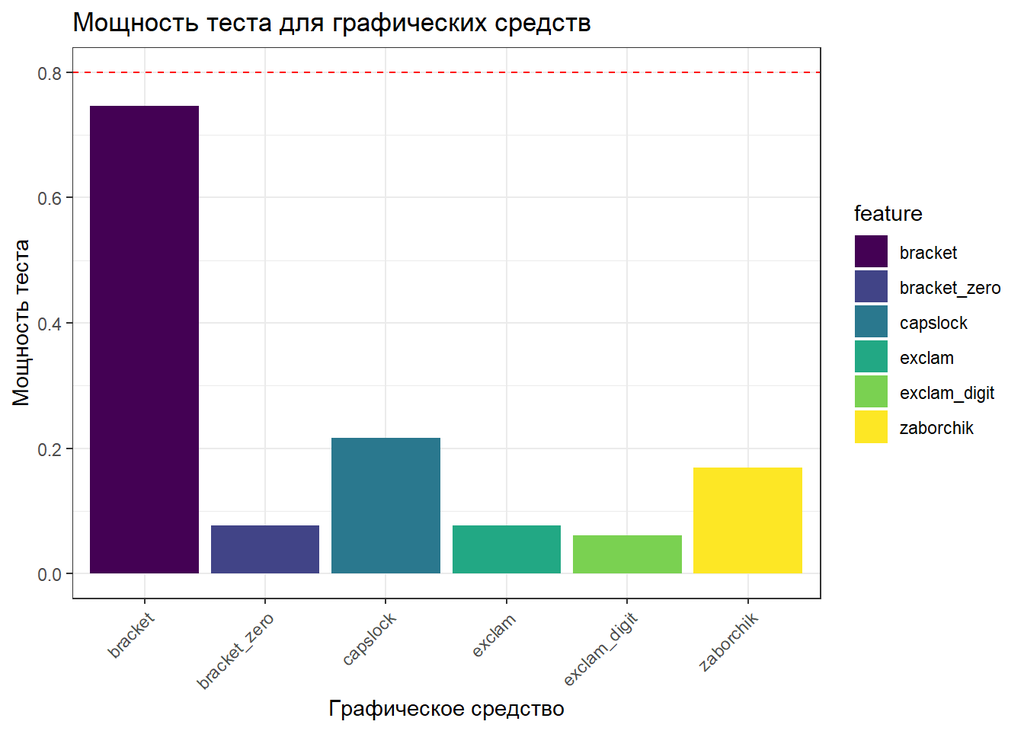

```r
ggplot(power_results, aes(x = feature, y = power, fill = feature)) +
  geom_col() +
  geom_hline(yintercept = 0.8, linetype = "dashed", color = "red") +
  labs(title = "Мощность теста для графических средств",
       x = "Графическое средство", y = "Мощность теста") +
  scale_fill_viridis_d() +
  theme_bw() +  # белый фон и серые сетки
  theme(axis.text.x = element_text(angle = 45, hjust = 1))
```

Анализ показал, что близок к общепринятому пороговому значению (0.8) только показатель мощности для скобок без нулей. На втором месте капслок, но мощность статистического теста для него чуть больше 0.2. Для зАбОрЧиКа показатель не превышает 0.2, а в остальных случаях значения даже меньше 0.1 Из этого следует, что относительно надёжным статистический тест будет только для скобок без нулей.

# Множественная регрессия с ковариатами

Попробуем проанализировать данные с помощью множественной регрессии с ковариатами. Во-первых, это позволит контролировать, как на оценку ироничности влияет не только использование конкретного графического средства, но и другие факторы: возраст респондента, знание терминов и т. д. Во-вторых, насколько я понимаю, уменьшится дисперсия остатков модели, повысив статистическую мощность и точность оценок: так, вероятно, появится возможность обнаружить мелкие, но всё же значимые эффекты. В-третьих, можно оценить взаимодействия между переменными (например, посмотреть, как эффект использования графического средства меняется в зависимости от типа стимула).

## Формула модели

rating ∼ use_numeric ∗ stimulus + age_scaled + is_aware_numeric

- rating — оценка ироничности
- use_numeric — индикатор использования графического средства (0/1)
- stimulus — тип графического стимула
- age_scaled — стандартизованный возраст
- is_aware_numeric — знание терминов (0/1)

```r
regression_data <- data_clean %>%
  pivot_longer(cols = ends_with("_rate"), names_to = "stimulus", values_to = "rating") %>%
  mutate(stimulus = str_remove(stimulus, "_rate")) %>%
  left_join(
    data_clean %>%
      select(user_id, ends_with("_use")) %>%
      pivot_longer(cols = -user_id, names_to = "stimulus", values_to = "use", names_pattern = "(.*)_use"),
    by = c("user_id", "stimulus")
  ) %>%
  mutate(
    use_numeric = if_else(use == "yes", 1, 0),
    is_aware_numeric = if_else(is_aware == "yes", 1, 0),
    age_scaled = scale(age)
  ) %>%
  filter(!is.na(rating), !is.na(use_numeric), !is.na(age_scaled), !is.na(is_aware_numeric))
model <- lm(rating ~ use_numeric * stimulus + age_scaled + is_aware_numeric, data = regression_data)
summary(model)
```

```
##
## Call:
## lm(formula = rating ~ use_numeric * stimulus + age_scaled + is_aware_numeric,
##     data = regression_data)
##
## Residuals:
##     Min      1Q  Median      3Q     Max
## -3.0850 -0.9208  0.0584  1.0017  2.6993
##
## Coefficients:
##                                  Estimate Std. Error t value Pr(>|t|)
## (Intercept)                       3.63217    0.13940  26.055  < 2e-16 ***
## use_numeric                       0.44837    0.20772   2.158  0.03118 *
## stimulusbracket_zero              0.40021    0.16640   2.405  0.01638 *
## stimuluscapslock                 -0.55259    0.16862  -3.277  0.00109 **
## stimulusexclam                   -1.22817    0.16639  -7.381 3.82e-13 ***
## stimulusexclam_digit             -0.31723    0.16617  -1.909  0.05660 .
## stimuluszaborchik                 0.23615    0.16777   1.408  0.15964
## age_scaled                        0.07691    0.04251   1.809  0.07080 .
## is_aware_numeric                 -0.06762    0.08643  -0.782  0.43419
## use_numeric:stimulusbracket_zero  0.57797    0.73019   0.792  0.42886
## use_numeric:stimuluscapslock      0.42421    0.41779   1.015  0.31023
## use_numeric:stimulusexclam        1.23579    0.73023   1.692  0.09096 .
## use_numeric:stimulusexclam_digit  1.31174    0.87946   1.492  0.13620
## use_numeric:stimuluszaborchik     0.22358    0.46256   0.483  0.62897
## ---
## Signif. codes:  0 '***' 0.001 '**' 0.01 '*' 0.05 '.' 0.1 ' ' 1
##
## Residual standard error: 1.2 on 826 degrees of freedom
## Multiple R-squared:  0.1997, Adjusted R-squared:  0.1871
## F-statistic: 15.85 on 13 and 826 DF,  p-value: < 2.2e-16
```

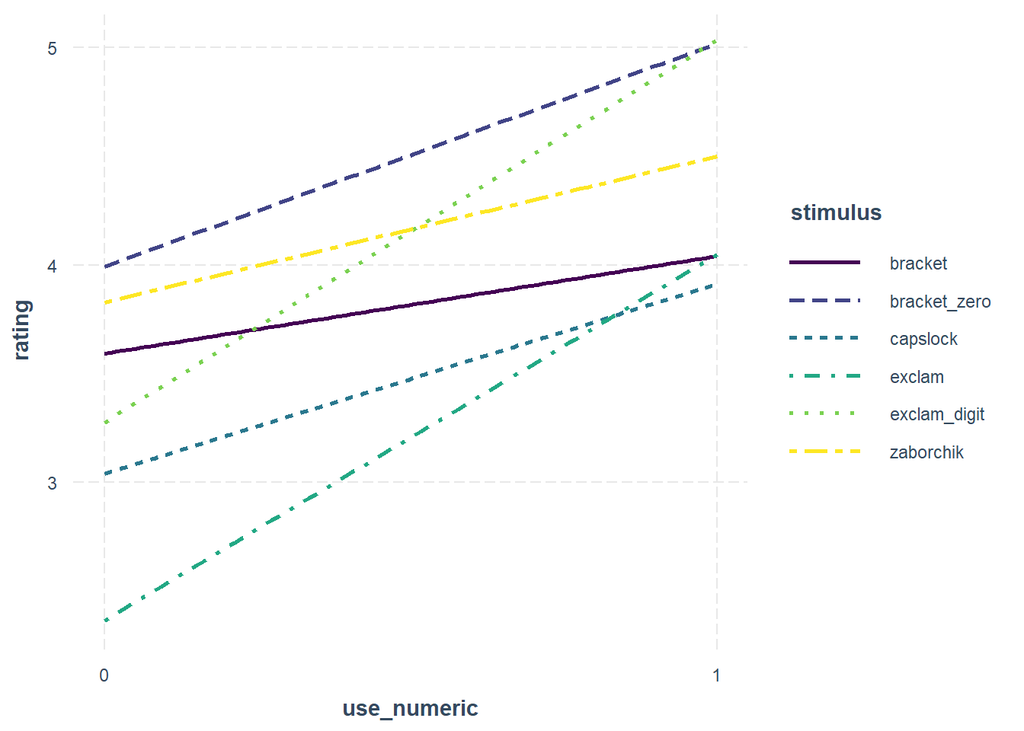

```r
# Визуализация взаимодействия

interact_plot(model, pred = use_numeric, modx = stimulus, colors = viridis(length(unique(regression_data$stimulus))))
```

По графику мы видим, что люди, использующие конкретное графическое средство выражения иронии, действительно оценивают его ироничность выше. Это подтверждает гипотезу проекта. Тем не менее этот и другие выводы стоит проверить на более крупной и разнообразной выборке, а также учесть, что множественная регрессия может не быть идеальным методом для анализа наших данных, поскольку оценка ироничности — дискретная переменная, а с помощью множественной регрессии принято анализировать непрерывные величины.

# Выводы

Проведенные статистические тесты и построенная регрессионная модель показывают, что использование определённых графических средств действительно связано с восприятием иронии и оцениванием того или иного типа оформления сообщения как более или менее явно указывающего на иронию.

# Дискуссия и ограничения

Помимо увеличения выборки и повышения её репрезентативности, в дальнейших исследованиях следует обратить внимание ещё на ряд факторов. В частности, может быть полезно пересмотреть дизайн проекта: рандомизировать порядок демонстрации стимулов респондентам, добавить контрольную группу или группы, ограничить время экспозиции.

Вероятно, есть смысл применить eye-tracking, поскольку анализируются исключительно графические средства. Кроме того, полезным будет провести интервью с репондентами, чтобы понять, как они декодируют иронию и какие эмоции у них вызывают исследуемые графические средства.

Стоит и более внимательно отнестись к оцениванию способности респондентов распознавать иронию в неформальной переписке. Если в этом проекте мы опирались на их собственные оценки, то в дальнейшем есть смысл применить специально разработанный тест — например, из работы Studying Irony Detection Beyond Ironic Criticism: Let’s Include Ironic Praise (Bruntsch & Ruch, 2017).

Можно также пересмотреть терминологию проекта и, в связи с этим, структуру опроса. Например, разграничить иронию и сарказм, как в одной из проанализированных работ (Katz, 2023), учесть характер ироничной реплики (ироничная похвала, ироничная критика и т. д.; Bruntsch & Ruch, 2017).

# Список литературы

1. Bruntsch R., Ruch W. (2017). Studying Irony Detection Beyond Ironic Criticism. Frontiers in Psychology 8:606.
2. Cambridge University Press (2023). The Cambridge Handbook of Irony and Thought.
3. GraphPad (2023). The power of nonparametric tests. Statistical Guides.
4. Katz A. (2023). Pictorial Irony and Sarcasm. The Cambridge Handbook of Irony and Thought (pp. 402-425).
5. Kosterin M., Paramonov I., & Lagutina N. (2023). Automatic Irony and Sarcasm Detection in Russian Sentences: Baseline Methods. Proceedings of the XXth Conference of Open Innovations Association FRUCT. 33. 148-154. 10.23919/FRUCT58615.2023.10142992.
6. ThisvsThat (2023). T Test vs. Wilcoxon Test. Comparative Analysis Platform.
7. Yus F. (2023). Inferring Irony Online. The Cambridge Handbook of Irony and Thought (pp. 160-180). Cambridge University Press.
8. Гуторенко Л. (2019). Комические креолизованные Интернет-мемы в русско-, испано- и англоязычной виртуальной коммуникации: лингвистический аспект и социокультурные особенности.